# Socioeconomic Deprivation, Genetics and Risk of Dementia

Data Documentation - Matthias Klee 2021-11-13

# Intro

This notebook includes the data documentation to the manuscript *Socioeconomic Deprivation, Genetic Risk and Incident Dementia*.

## Folder structure

Folders contained in the project are the following: * ./data should contain prepared data files after fetching, imputing and preprocessing (e.g. genetic risk score computation) * ./plots will contain main figures after running the markdown code * ./code contains scripts including function definitions

## Instructions

You have two options to use this data documentation: You can either, * read the already knitted pdf document including all graphs and tables of the main document, * or run the markdown code chunks, thereby retrieving graphs and tables in place.

In the latter case, you need to fetch and preprocess the data yourself. Preprocessing steps involve, amongst other things, application of eligibility criteria, computation of survival times, identification of dementia cases, imputation of missing data, computation of the genetic risk and healthy lifestyle score as well as computation and classification of individual- and area-level socioeconomic deprivation groups. These steps result in 5 equally sized imputed data files (for which results will be pooled) and 1 complete case data file. The 6 files should be stored in ./data. You can then continue to open the markdown file ./20210104_Deprivation_x_Genetics.Rmd and run single chunks consecutively or knit the document at once. Please note the required packages listed below.

- tidyverse
- knitr
- survival
- broom
- mice
- scales
- ggplot2
- datawizard
- haven
- epiR
- ipw
- survey
- cobalt

```r
# setup
knitr::opts_chunk$set(echo=FALSE)
knitr::opts_chunk$set(cache=TRUE)
knitr::opts_chunk$set(message=FALSE)
knitr::opts_chunk$set(warning=FALSE)
```

You can then either load your data following the naming conventions that are illustrated in the code chunk below or adapt the markdown file to match your naming with regard to data files and column names.

| Variable | Definition | Type | Scale |
| --- | --- | --- | --- |
| f.eid | unique identifier | numeric | continuous |
| inc.dem2 | incident all-cause dementia | numeric | 0/1 |
| duryears | survival time | numeric | continuous |
| age | age | numeric | continuous |
| sex | sex | factor | 0/1 |
| edu_new | education | factor | high/medium/low/prefer not to answer, none of the above |
| marital_status | living situation | factor | partner, wife, husband/other |
| employment_status | retirement status | factor | retired/employed/other |
| n_ppl_in_hh | number of people living in the household | numeric | continuous |
| cwlife2 | healthy lifestyle | character | favorable/intermediate/unfavorable/prefer not to answer |
| depress2 | depressive symptoms in the last two weeks | factor | never/other |
| pc1 - 20 | principal components of ancestry | numeric | continuous |
| cnt1 | number of SNPs included to compute the polygenic risk score | numeric | continuous |
| degree3 | degree 3 relatedness | factor | 0/1 |
| Sprs | polygenic risk score | numeric | continuous |
| score_accommodation_asset | household ownership | factor | 0/1 |
| score_vehicles | car ownership | factor | 0/1 |
| score_accommodation_type | household type/living in a house | factor | 0/1 |
| wwealth | individual socioeconomic deprivation | numeric | continuous |
| cwwealth_inc | individual socioeconomic deprivation | factor | low deprivation/intermediate deprivation/high deprivation |
| wealth_Sprs | combined individual socioeconomic deprivation and genetic risk | factor | Q1 (low risk) Q5 (high deprivation)/Q1 (low risk) Q2-4 (intermediate deprivation)/Q1 (low risk) Q1 (low deprivation)/Q2-4 (intermediate risk) Q5 (high deprivation)/Q2-4 (intermediate risk) Q2-4 (inter… |
| tdi | Townsend Deprivation Index | numeric | continuous |
| tdi_bin | area socioeconomic deprivation | factor | Q1-4/Q5 |
| tdi_Sprs | combined area socioeconomic deprivation and genetic risk | factor | Q1 (low risk) Q1-4 (low-to-moderate deprivation)/Q1 (low risk) Q5 (high deprivation)/Q2-4 (intermediate risk) Q1-4 (low-to-moderate deprivation)/Q2-4 (intermediate risk) Q5 (high deprivation)/Q5 (high… |
| f.54.2.0 | visit location at T2 | numeric | 11025/11026/11027/11028 |
| f.53.0.0 / f.53.2.0 | visit date at T0 (baseline) and T2 | date | NA |
| f.25781.2.0 | WMH burden | numeric | continuous |
| f.25020.2.0 | volume of Hippocampus (r) | numeric | continuous |
| f.25019.2.0 | volume of Hippocampus (l) | numeric | continuous |
| f.25006.2.0 | volume of Grey Matter | numeric | continuous |
| f.25008.2.0 | volume of White Matter | numeric | continuous |
| f.25010.2.0 | volume of Whole Brain | numeric | continuous |

# Analyses

## Table 1. Baseline Characteristics of Participants.

[output not shown]

## Table 2. Risk of Incident Dementia by Area-Level Socioeconomic Deprivation Category

[output not shown]

## Table 3. Risk of Incident Dementia by Individual-Level Socioeconomic Deprivation Category

| Individual-Level Socioeconomic Deprivation | Total No. | No. of dementia cases/person-years | HR (95% CI) | P value | P value for trend |
| --- | --- | --- | --- | --- | --- |
| Model 1 |  |  |  |  |  |
| low deprivation | 39274 | 174 / 309221 | 1 [Reference] |  |  |
| intermediate deprivation | 117821 | 1042 / 929551 | 1.63 (1.38-1.93) | <.001 |  |
| high deprivation | 39273 | 553 / 306541 | 2.57 (2.14-3.08) | <.001 | <.001 |
| Model 2 |  |  |  |  |  |
| low deprivation | 39274 | 174 / 309221 | 1 [Reference] |  |  |
| intermediate deprivation | 117821 | 1042 / 929551 | 1.63 (1.38-1.93) | <.001 |  |
| high deprivation | 39273 | 553 / 306541 | 2.57 (2.14-3.09) | <.001 | <.001 |
| Model 3 |  |  |  |  |  |
| low deprivation | 39274 | 174 / 309221 | 1 [Reference] |  |  |
| intermediate deprivation | 117821 | 1042 / 929551 | 1.62 (1.37-1.92) | <.001 |  |
| high deprivation | 39273 | 553 / 306541 | 2.38 (1.98-2.87) | <.001 | <.001 |

## Figure 1. Risk of Incident Dementia for A Area-Level and B Individual-Level Socioeconomic Deprivation with Genetic Risk

### Results Table for A

| Deprivation and Genetic Risk | Total No. of participants | No. of dementia cases/person-years | HR (95% CI) | Lower CI | Upper CI | P Value |
| --- | --- | --- | --- | --- | --- | --- |
| Q1 (low risk) Q1-4 (low-to-moderate deprivation) | 31648 | 177 / 249647 | 1 [Reference] |  |  |  |
| Q1 (low risk) Q5 (high deprivation) | 7626 | 70 / 59124 | 1.305 | 0.986 | 1.729 | 0.063 |
| Q2-4 (intermediate risk) Q1-4 (low-to-moderate deprivation) | 94316 | 744 / 744724 | 1.393 | 1.182 | 1.642 | <.001 |
| Q2-4 (intermediate risk) Q5 (high deprivation) | 23505 | 294 / 182389 | 1.715 | 1.413 | 2.08 | <.001 |
| Q5 (high risk) Q1-4 (low-to-moderate deprivation) | 31131 | 345 / 246144 | 1.961 | 1.634 | 2.352 | <.001 |
| Q5 (high risk) Q5 (high deprivation) | 8142 | 139 / 63285 | 2.31 | 1.836 | 2.907 | <.001 |

### Plot for A

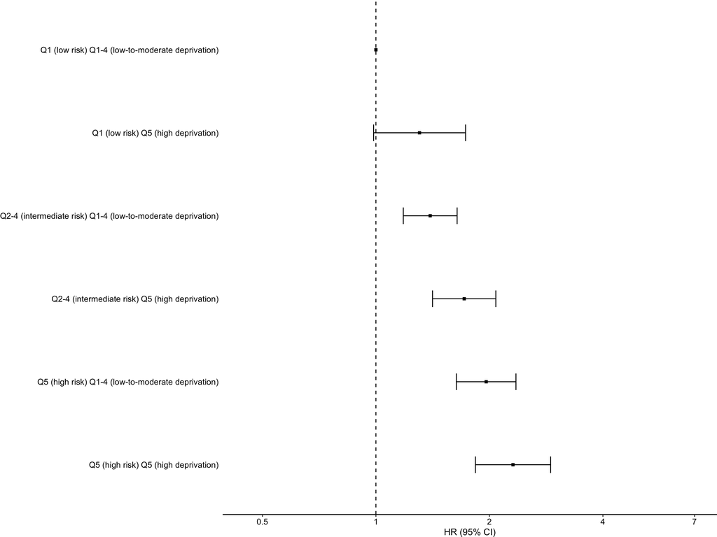

### Results Table for B

| Deprivation and Genetic Risk | Total No. of participants | No. of dementia cases/person-years | HR (95% CI) | Lower CI | Upper CI | P Value |
| --- | --- | --- | --- | --- | --- | --- |
| Q1 (low risk) Q1 (low deprivation) | 8110 | 25 / 63790 | NA | NA | NA | NA |
| Q1 (low risk) Q2-4 (intermediate deprivation) | 23624 | 134 / 186093 | 1.497 | 0.973 | 2.303 | 0.066 |
| Q1 (low risk) Q5 (high deprivation) | 7540 | 88 / 58887 | 2.692 | 1.709 | 4.241 | <.001 |
| Q2-4 (intermediate risk) Q1 (low deprivation) | 23417 | 103 / 184307 | 1.419 | 0.916 | 2.197 | 0.117 |
| Q2-4 (intermediate risk) Q2-4 (intermediate deprivation) | 70774 | 614 / 558529 | 2.243 | 1.499 | 3.356 | <.001 |
| Q2-4 (intermediate risk) Q5 (high deprivation) | 23630 | 321 / 184276 | 3.124 | 2.06 | 4.737 | <.001 |
| Q5 (high risk) Q1 (low deprivation) | 7747 | 46 / 61124 | 1.949 | 1.197 | 3.174 | 0.007 |
| Q5 (high risk) Q2-4 (intermediate deprivation) | 23423 | 294 / 184928 | 3.237 | 2.144 | 4.887 | <.001 |
| Q5 (high risk) Q5 (high deprivation) | 8103 | 144 / 63377 | 4.057 | 2.631 | 6.257 | <.001 |

### Plot for B

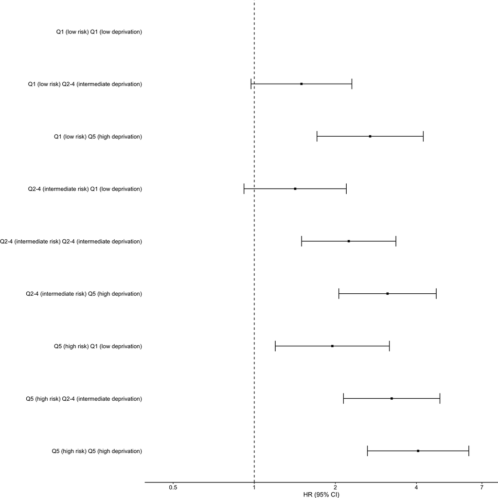

# Appendix

## eTable 1. Coefficients of Cox Proportional-Hazards Regressions Used for Weighting of the Individual-Level Socioeconomic Deprivation Score

```
## Non-disclosed socioeconomic information included in 'other' or as a separate category (for income only)
```

| term | Coefficient (95% CI) | P value | Total |
| --- | --- | --- | --- |
| Income |  |  |  |
| income greater 31,000 | 0 [Reference] |  | 53346 |
| income up to 30,999 | 0.34 (0.18-0.50) | <.001 | 52834 |
| income up to 18,000 | 0.48 (0.31-0.65) | <.001 | 54866 |
| income not disclosed | 0.67 (0.50-0.85) | <.001 | 35322 |
| Housing Type |  |  |  |
| house or flat | 0 [Reference] |  | 194542 |
| other | 0.45 (0.11-0.78) | 0.009 | 1826 |
| Home Ownership |  |  |  |
| own outright | 0 [Reference] |  | 151971 |
| other | 0.35 (0.24-0.46) | <.001 | 44397 |
| Car Ownership |  |  |  |
| one or more | 0 [Reference] |  | 179091 |
| other | 0.32 (0.18-0.46) | <.001 | 17277 |

```
## Non-disclosed socioeconomic information excluded
```

| term | Coefficient (95% CI) | P value | Total |
| --- | --- | --- | --- |
| Income |  |  |  |
| income greater 31,000 | 0 [Reference] |  | 53146 |
| income up to 30,999 | 0.38 (0.21-0.54) | <.001 | 52572 |
| income up to 18,000 | 0.54 (0.36-0.71) | <.001 | 54339 |
| Housing Type |  |  |  |
| house or flat | 0 [Reference] |  | 159059 |
| other | 0.74 (0.33-1.14) | <.001 | 998 |
| Home Ownership |  |  |  |
| own outright | 0 [Reference] |  | 123790 |
| other | 0.39 (0.26-0.52) | <.001 | 36267 |
| Car Ownership |  |  |  |
| one or more | 0 [Reference] |  | 146778 |
| other | 0.29 (0.12-0.45) | <.001 | 13279 |

## eTable 2. Total Participants and Incident Dementia Cases in Area-Level Socioeconomic Deprivation Groups

| Area-Level Socioeconomic Deprivation | No. of Dementia Cases | Total No. | Absolute Risk | CI Lower | CI Upper | Incidence Rates per 1,000 Person-Years | CI lower | CI upper |
| --- | --- | --- | --- | --- | --- | --- | --- | --- |
| low-to-moderate deprivation | 1266 | 157095 | 0.81 | 0.76 | 0.85 | 1.02 | 0.97 | 1.08 |
| high deprivation | 503 | 39273 | 1.28 | 1.17 | 1.40 | 1.65 | 1.51 | 1.80 |

## eTable 3. Total Participants and Incident Dementia Cases in Individual-Level Socioeconomic Deprivation Groups

| Individual-Level Socioeconomic Deprivation | No. of Dementia Cases | Total No. | Absolute Risk | CI Lower | CI Upper | Incidence Rates per 1,000 Person-Years | CI lower | CI upper |
| --- | --- | --- | --- | --- | --- | --- | --- | --- |
| low deprivation | 174 | 39274 | 0.44 | 0.38 | 0.51 | 0.56 | 0.48 | 0.65 |
| intermediate deprivation | 1042 | 117821 | 0.88 | 0.83 | 0.94 | 1.12 | 1.05 | 1.19 |
| high deprivation | 553 | 39273 | 1.41 | 1.29 | 1.53 | 1.80 | 1.66 | 1.96 |

## eTable 4. Total Participants and Incident Dementia Cases According to Area-Level Socioeconomic Deprivation within Each Genetic Risk Category

| Area-Level Socioeconomic Deprivation | Genetic Risk | No. of Dementia Cases | Total No. | Absolute Risk | CI Lower | CI Upper | Incidence Rates per 1,000 Person-Years | CI lower | CI upper |
| --- | --- | --- | --- | --- | --- | --- | --- | --- | --- |
| low-to-moderate deprivation | Q1 | 177 | 31648 | 0.56 | 0.48 | 0.65 | 0.71 | 0.61 | 0.82 |
| low-to-moderate deprivation | Q2-4 | 744 | 94316 | 0.79 | 0.73 | 0.85 | 1.00 | 0.93 | 1.07 |
| low-to-moderate deprivation | Q5 | 345 | 31131 | 1.11 | 0.99 | 1.23 | 1.40 | 1.26 | 1.56 |
| high deprivation | Q1 | 70 | 7626 | 0.92 | 0.72 | 1.16 | 1.18 | 0.92 | 1.50 |
| high deprivation | Q2-4 | 294 | 23505 | 1.25 | 1.11 | 1.40 | 1.61 | 1.43 | 1.81 |
| high deprivation | Q5 | 139 | 8142 | 1.71 | 1.44 | 2.01 | 2.20 | 1.85 | 2.59 |

## eTable 5. Total Participants and Incident Dementia Cases According to Individual-Level Socioeconomic Deprivation within Each Genetic Risk Category

| Individual-Level Socioeconomic Deprivation | Genetic Risk | No. of Dementia Cases | Total No. | Absolute Risk | CI Lower | CI Upper | Incidence Rates per 1,000 Person-Years | CI lower | CI upper |
| --- | --- | --- | --- | --- | --- | --- | --- | --- | --- |
| low deprivation | Q1 | 25 | 8110 | 0.31 | 0.20 | 0.45 | 0.39 | 0.25 | 0.58 |
| low deprivation | Q2-4 | 103 | 23417 | 0.44 | 0.36 | 0.53 | 0.56 | 0.46 | 0.68 |
| low deprivation | Q5 | 46 | 7747 | 0.59 | 0.44 | 0.79 | 0.75 | 0.55 | 1.00 |
| intermediate deprivation | Q1 | 134 | 23624 | 0.57 | 0.48 | 0.67 | 0.72 | 0.60 | 0.85 |
| intermediate deprivation | Q2-4 | 614 | 70774 | 0.87 | 0.80 | 0.94 | 1.10 | 1.01 | 1.19 |
| intermediate deprivation | Q5 | 294 | 23423 | 1.26 | 1.12 | 1.41 | 1.59 | 1.41 | 1.78 |
| high deprivation | Q1 | 88 | 7540 | 1.17 | 0.94 | 1.44 | 1.49 | 1.20 | 1.84 |
| high deprivation | Q2-4 | 321 | 23630 | 1.36 | 1.21 | 1.51 | 1.74 | 1.56 | 1.94 |
| high deprivation | Q5 | 144 | 8103 | 1.78 | 1.50 | 2.09 | 2.27 | 1.92 | 2.67 |

### Imputed Data

```
## Log-transformed WMH burden
```

Variable = f.25781.2.0 (Total No. = 11035)

| term | Coefficient (95% CI) | SE | P value |
| --- | --- | --- | --- |
| Individual Deprivation Intermediate | 0.04 (-0.01-0.09) | 0.03 | 0.085 |
| Individual Deprivation High | 0.10 (0.01-0.19) | 0.04 | 0.033 |
| Area Deprivation High | 0.07 (0.01-0.14) | 0.04 | 0.032 |

| term | Coefficient (95% CI) | SE | P value |
| --- | --- | --- | --- |
| Individual Deprivation Intermediate | 0.05 (0.00-0.10) | 0.03 | 0.044 |
| Individual Deprivation High | 0.10 (0.01-0.19) | 0.04 | 0.031 |
| Area Deprivation High | 0.08 (0.01-0.15) | 0.04 | 0.031 |

```
## Right hippocampus volume
```

Variable = f.25020.2.0 (Total No. = 10838)

| term | Coefficient (95% CI) | SE | P value |
| --- | --- | --- | --- |
| Individual Deprivation Intermediate | -0.04 (-0.09-0.01) | 0.03 | 0.148 |
| Individual Deprivation High | -0.01 (-0.10-0.08) | 0.05 | 0.877 |
| Area Deprivation High | -0.04 (-0.11-0.03) | 0.04 | 0.266 |

| term | Coefficient (95% CI) | SE | P value |
| --- | --- | --- | --- |
| Individual Deprivation Intermediate | -0.03 (-0.09-0.02) | 0.03 | 0.182 |
| Individual Deprivation High | -0.00 (-0.09-0.09) | 0.05 | 0.935 |
| Area Deprivation High | -0.04 (-0.11-0.03) | 0.04 | 0.260 |

```
## Left hippocampus volume
```

Variable = f.25019.2.0 (Total No. = 10920)

| term | Coefficient (95% CI) | SE | P value |
| --- | --- | --- | --- |
| Individual Deprivation Intermediate | -0.05 (-0.10-0.00) | 0.03 | 0.055 |
| Individual Deprivation High | -0.01 (-0.10-0.09) | 0.04 | 0.912 |
| Area Deprivation High | -0.06 (-0.13-0.01) | 0.04 | 0.078 |

| term | Coefficient (95% CI) | SE | P value |
| --- | --- | --- | --- |
| Individual Deprivation Intermediate | -0.05 (-0.10-0.00) | 0.03 | 0.059 |
| Individual Deprivation High | -0.01 (-0.09-0.08) | 0.04 | 0.908 |
| Area Deprivation High | -0.06 (-0.13-0.01) | 0.04 | 0.074 |

```
## Whole brain volume
```

Variable = f.25010.2.0 (Total No. = 11035)

| term | Coefficient (95% CI) | SE | P value |
| --- | --- | --- | --- |
| Individual Deprivation Intermediate | -0.03 (-0.08-0.02) | 0.03 | 0.300 |
| Individual Deprivation High | -0.03 (-0.12-0.06) | 0.05 | 0.493 |
| Area Deprivation High | -0.05 (-0.12-0.02) | 0.04 | 0.187 |

| term | Coefficient (95% CI) | SE | P value |
| --- | --- | --- | --- |
| Individual Deprivation Intermediate | -0.03 (-0.08-0.02) | 0.03 | 0.250 |
| Individual Deprivation High | -0.03 (-0.12-0.06) | 0.04 | 0.464 |
| Area Deprivation High | -0.05 (-0.12-0.02) | 0.04 | 0.168 |

```
## White matter volume
```

Variable = f.25008.2.0 (Total No. = 11039)

| term | Coefficient (95% CI) | SE | P value |
| --- | --- | --- | --- |
| Individual Deprivation Intermediate | 0.01 (-0.04-0.06) | 0.03 | 0.821 |
| Individual Deprivation High | -0.02 (-0.10-0.07) | 0.04 | 0.670 |
| Area Deprivation High | 0.02 (-0.05-0.09) | 0.04 | 0.589 |

| term | Coefficient (95% CI) | SE | P value |
| --- | --- | --- | --- |
| Individual Deprivation Intermediate | -0.00 (-0.05-0.05) | 0.03 | 0.914 |
| Individual Deprivation High | -0.02 (-0.10-0.06) | 0.04 | 0.596 |
| Area Deprivation High | 0.02 (-0.05-0.09) | 0.04 | 0.633 |

```
## Grey matter volume
```

Variable = f.25006.2.0 (Total No. = 11018)

| term | Coefficient (95% CI) | SE | P value |
| --- | --- | --- | --- |
| Individual Deprivation Intermediate | -0.05 (-0.10–0.00) | 0.03 | 0.043 |
| Individual Deprivation High | -0.04 (-0.14-0.05) | 0.05 | 0.347 |
| Area Deprivation High | -0.11 (-0.18–0.03) | 0.04 | 0.004 |

| term | Coefficient (95% CI) | SE | P value |
| --- | --- | --- | --- |
| Individual Deprivation Intermediate | -0.05 (-0.10-0.00) | 0.03 | 0.066 |
| Individual Deprivation High | -0.04 (-0.14-0.05) | 0.05 | 0.387 |
| Area Deprivation High | -0.11 (-0.18–0.04) | 0.04 | 0.004 |

### Complete Cases

```
## Log-transformed WMH burden
```

Variable = f.25781.2.0 (Total No. = 8131)

| term | Coefficient (95% CI) | SE | P value |
| --- | --- | --- | --- |
| Individual Deprivation Intermediate | 0.05 (-0.01-0.10) | 0.03 | 0.083 |
| Individual Deprivation High | 0.06 (-0.06-0.17) | 0.06 | 0.343 |
| Area Deprivation High | 0.07 (-0.03-0.16) | 0.05 | 0.173 |

| term | Coefficient (95% CI) | SE | P value |
| --- | --- | --- | --- |
| Individual Deprivation Intermediate | 0.06 (0.00-0.12) | 0.03 | 0.038 |
| Individual Deprivation High | 0.06 (-0.06-0.17) | 0.06 | 0.327 |
| Area Deprivation High | 0.07 (-0.03-0.17) | 0.05 | 0.155 |

```
## Right hippocampus volume
```

Variable = f.25020.2.0 (Total No. = 7999)

| term | Coefficient (95% CI) | SE | P value |
| --- | --- | --- | --- |
| Individual Deprivation Intermediate | -0.04 (-0.10-0.02) | 0.03 | 0.163 |
| Individual Deprivation High | 0.03 (-0.08-0.15) | 0.06 | 0.554 |
| Area Deprivation High | -0.00 (-0.09-0.09) | 0.04 | 0.997 |

| term | Coefficient (95% CI) | SE | P value |
| --- | --- | --- | --- |
| Individual Deprivation Intermediate | -0.04 (-0.09-0.02) | 0.03 | 0.199 |
| Individual Deprivation High | 0.04 (-0.07-0.15) | 0.06 | 0.496 |
| Area Deprivation High | 0.00 (-0.09-0.09) | 0.04 | 0.982 |

```
## Left hippocampus volume
```

Variable = f.25019.2.0 (Total No. = 8056)

| term | Coefficient (95% CI) | SE | P value |
| --- | --- | --- | --- |
| Individual Deprivation Intermediate | -0.03 (-0.08-0.03) | 0.03 | 0.321 |
| Individual Deprivation High | 0.07 (-0.04-0.18) | 0.06 | 0.217 |
| Area Deprivation High | -0.05 (-0.14-0.04) | 0.05 | 0.287 |

| term | Coefficient (95% CI) | SE | P value |
| --- | --- | --- | --- |
| Individual Deprivation Intermediate | -0.03 (-0.08-0.03) | 0.03 | 0.368 |
| Individual Deprivation High | 0.07 (-0.04-0.18) | 0.06 | 0.216 |
| Area Deprivation High | -0.05 (-0.14-0.04) | 0.05 | 0.260 |

```
## Whole brain volume
```

Variable = f.25010.2.0 (Total No. = 8139)

| term | Coefficient (95% CI) | SE | P value |
| --- | --- | --- | --- |
| Individual Deprivation Intermediate | -0.02 (-0.08-0.03) | 0.03 | 0.391 |
| Individual Deprivation High | 0.08 (-0.03-0.18) | 0.05 | 0.151 |
| Area Deprivation High | -0.00 (-0.09-0.09) | 0.04 | 0.937 |

| term | Coefficient (95% CI) | SE | P value |
| --- | --- | --- | --- |
| Individual Deprivation Intermediate | -0.03 (-0.08-0.03) | 0.03 | 0.312 |
| Individual Deprivation High | 0.07 (-0.03-0.18) | 0.05 | 0.165 |
| Area Deprivation High | 0.00 (-0.09-0.09) | 0.04 | 0.990 |

```
## White matter volume
```

Variable = f.25008.2.0 (Total No. = 8140)

| term | Coefficient (95% CI) | SE | P value |
| --- | --- | --- | --- |
| Individual Deprivation Intermediate | 0.02 (-0.04-0.07) | 0.03 | 0.496 |
| Individual Deprivation High | 0.06 (-0.04-0.17) | 0.05 | 0.256 |
| Area Deprivation High | 0.02 (-0.08-0.11) | 0.05 | 0.738 |

| term | Coefficient (95% CI) | SE | P value |
| --- | --- | --- | --- |
| Individual Deprivation Intermediate | 0.01 (-0.04-0.06) | 0.03 | 0.750 |
| Individual Deprivation High | 0.06 (-0.05-0.16) | 0.05 | 0.301 |
| Area Deprivation High | 0.02 (-0.07-0.12) | 0.05 | 0.648 |

```
## Grey matter volume
```

Variable = f.25006.2.0 (Total No. = 8128)

| term | Coefficient (95% CI) | SE | P value |
| --- | --- | --- | --- |
| Individual Deprivation Intermediate | -0.06 (-0.12–0.01) | 0.03 | 0.031 |
| Individual Deprivation High | 0.03 (-0.07-0.14) | 0.05 | 0.546 |
| Area Deprivation High | -0.04 (-0.13-0.06) | 0.05 | 0.430 |

| term | Coefficient (95% CI) | SE | P value |
| --- | --- | --- | --- |
| Individual Deprivation Intermediate | -0.06 (-0.12–0.00) | 0.03 | 0.046 |
| Individual Deprivation High | 0.04 (-0.07-0.14) | 0.05 | 0.496 |
| Area Deprivation High | -0.04 (-0.13-0.06) | 0.05 | 0.431 |

## eTable 12. Risk of Incident Dementia According to Combined Area-Level Socioeconomic Deprivation and Genetic Risk in Complete-Case Data

| Genetic risk and deprivation | Total No. of participants | No. of dementia cases/person-years | HR (95% CI) | P value |
| --- | --- | --- | --- | --- |
| Q1 (low risk) Q1-4 (low-to-moderate deprivation) | 22154 | 120 / 173636 | 1 [Reference] |  |
| Q1 (low risk) Q5 (high deprivation) | 3875 | 31 / 29809 | 1.26 (0.85-1.88) | 0.249 |
| Q2-4 (intermediate risk) Q1-4 (low-to-moderate deprivation) | 66516 | 488 / 521545 | 1.34 (1.10-1.64) | 0.004 |
| Q2-4 (intermediate risk) Q5 (high deprivation) | 11927 | 138 / 92019 | 1.76 (1.37-2.25) | <.001 |
| Q5 (high risk) Q1-4 (low-to-moderate deprivation) | 21778 | 215 / 171055 | 1.81 (1.45-2.27) | <.001 |
| Q5 (high risk) Q5 (high deprivation) | 4055 | 50 / 31449 | 1.80 (1.29-2.52) | <.001 |

## eTable 13. Risk of Incident Dementia According to Combined Individual-Level Socioeconomic Deprivation and Genetic Risk in Complete-Case Data

| Genetic risk and deprivation | Total No. of participants | No. of dementia cases/person-years | HR (95% CI) | P value |
| --- | --- | --- | --- | --- |
| Q1 (low risk) Q1 (low deprivation) | 6849 | 23 / 53656 | 1 [Reference] |  |
| Q1 (low risk) Q2-4 (intermediate deprivation) | 15696 | 89 / 122655 | 1.37 (0.86-2.17) | 0.184 |
| Q1 (low risk) Q5 (high deprivation) | 3484 | 39 / 27133 | 2.29 (1.36-3.86) | 0.002 |
| Q2-4 (intermediate risk) Q1 (low deprivation) | 19790 | 84 / 155026 | 1.26 (0.79-2.00) | 0.328 |
| Q2-4 (intermediate risk) Q2-4 (intermediate deprivation) | 47819 | 399 / 374404 | 1.97 (1.29-3.01) | 0.002 |
| Q2-4 (intermediate risk) Q5 (high deprivation) | 10834 | 143 / 84132 | 2.75 (1.75-4.31) | <.001 |
| Q5 (high risk) Q1 (low deprivation) | 6554 | 39 / 51460 | 1.80 (1.07-3.01) | 0.026 |
| Q5 (high risk) Q2-4 (intermediate deprivation) | 15593 | 174 / 122193 | 2.63 (1.69-4.08) | <.001 |
| Q5 (high risk) Q5 (high deprivation) | 3686 | 52 / 28852 | 2.89 (1.75-4.76) | <.001 |

## eTable 14. Risk of Dementia According to Area-Level Socioeconomic Deprivation in Subgroups Stratified by Genetic Risk

| Area-Level Socioeconomic Deprivation | Total No. | No. of dementia cases/person-years | HR (95% CI) | P value |
| --- | --- | --- | --- | --- |
| Model 1 |  |  |  |  |
| low-to-moderate deprivation | 31648 | 177 / 249647 | 1 [Reference] |  |
| high deprivation | 7626 | 70 / 59124 | 1.18 (0.87-1.61) | 0.287 |
| Model 2 |  |  |  |  |
| low-to-moderate deprivation | 94316 | 744 / 744724 | 1 [Reference] |  |
| high deprivation | 23505 | 294 / 182389 | 1.29 (1.11-1.50) | <.001 |
| Model 3 |  |  |  |  |
| low-to-moderate deprivation | 31131 | 345 / 246144 | 1 [Reference] |  |
| high deprivation | 8142 | 139 / 63285 | 1.32 (1.06-1.64) | 0.014 |

## eTable 15. Risk of Dementia According to Individual-Level Socioeconomic Deprivation in Genetic Risk Strata

| Individual-Level Socioeconomic Deprivation | Total No. | No. of dementia cases/person-years | HR (95% CI) | P value | P value for trend |
| --- | --- | --- | --- | --- | --- |
| Model 1 |  |  |  |  |  |
| low deprivation | 8110 | 25 / 63790 | 1 [Reference] |  |  |
| intermediate deprivation | 23624 | 134 / 186093 | 1.50 (0.96-2.35) | 0.074 |  |
| high deprivation | 7540 | 88 / 58887 | 2.73 (1.66-4.50) | <.001 | <.001 |
| Model 2 |  |  |  |  |  |
| low deprivation | 23417 | 103 / 184307 | 1 [Reference] |  |  |
| intermediate deprivation | 70774 | 614 / 558529 | 1.61 (1.29-2.00) | <.001 |  |
| high deprivation | 23630 | 321 / 184276 | 2.34 (1.83-2.99) | <.001 | <.001 |
| Model 3 |  |  |  |  |  |
| low deprivation | 7747 | 46 / 61124 | 1 [Reference] |  |  |
| intermediate deprivation | 23423 | 294 / 184928 | 1.72 (1.25-2.38) | <.001 |  |
| high deprivation | 8103 | 144 / 63377 | 2.31 (1.61-3.32) | <.001 | <.001 |

## eTable 16. Risk of Dementia According to Area-Level Socioeconomic Deprivation in Subgroups Stratified by Sex

| Area-Level Socioeconomic Deprivation | Total No. | No. of dementia cases/person-years | HR (95% CI) | P value |
| --- | --- | --- | --- | --- |
| Model 1 |  |  |  |  |
| low-to-moderate deprivation | 82938 | 569 / 659247 | 1 [Reference] |  |
| high deprivation | 20496 | 221 / 161207 | 1.25 (1.05-1.48) | 0.011 |
| Model 2 |  |  |  |  |
| low-to-moderate deprivation | 74157 | 697 / 581268 | 1 [Reference] |  |
| high deprivation | 18777 | 282 / 143591 | 1.31 (1.12-1.53) | <.001 |

## eTable 17. Risk of Dementia According to Individual-Level Socioeconomic Deprivation in Subgroups Stratified by Sex

| Individual-Level Socioeconomic Deprivation | Total No. | No. of dementia cases/person-years | HR (95% CI) | P value | P value for trend |
| --- | --- | --- | --- | --- | --- |
| Model 1 |  |  |  |  |  |
| low deprivation | 16617 | 57 / 131217 | 1 [Reference] |  |  |
| intermediate deprivation | 65137 | 467 / 517550 | 1.51 (1.14-2.00) | 0.004 |  |
| high deprivation | 21680 | 266 / 171687 | 2.29 (1.68-3.13) | <.001 | <.001 |
| Model 2 |  |  |  |  |  |
| low deprivation | 22657 | 117 / 178004 | 1 [Reference] |  |  |
| intermediate deprivation | 52684 | 575 / 412001 | 1.71 (1.39-2.10) | <.001 |  |
| high deprivation | 17593 | 287 / 134854 | 2.44 (1.92-3.11) | <.001 | <.001 |

## eTable 18. Proportion of Individual-Level Socioeconomic Deprivation Across Lifestyle Categories in Complete-Case Data and Imputed Data for the Full Sample and Imaging Subsample

### Full Sample

```
## Complete Cases
```

| Lifestyle | low deprivation | intermediate deprivation | high deprivation | NA | total |
| --- | --- | --- | --- | --- | --- |
| favorable | 19.79 | 60.13 | 20.08 | 79 | 32761 |
| intermediate | 22.94 | 61.06 | 15.99 | 419 | 98104 |
| unfavorable | 20.94 | 56.87 | 22.19 | 282 | 32559 |
| NA | 10.21 | 59.79 | 30.00 | 250 | 31914 |

```
## Imputed Data
```

| Lifestyle | low deprivation | intermediate deprivation | high deprivation | total |
| --- | --- | --- | --- | --- |
| favorable | 17.44 | 64.87 | 17.69 | 39273 |
| intermediate | 20.90 | 60.26 | 18.84 | 117821 |
| unfavorable | 19.88 | 54.35 | 25.78 | 39274 |

### Imaging Subset

```
## Complete Cases
```

| Lifestyle | low deprivation | intermediate deprivation | high deprivation | NA | total |
| --- | --- | --- | --- | --- | --- |
| favorable | 29.27 | 58.53 | 12.20 | 8 | 2033 |
| intermediate | 33.68 | 58.40 | 7.92 | 29 | 6123 |
| unfavorable | 37.70 | 54.00 | 8.30 | 8 | 1626 |
| NA | 19.39 | 65.46 | 15.14 | 8 | 1248 |

```
## Imputed Data
```

| Lifestyle | low deprivation | intermediate deprivation | high deprivation | total |
| --- | --- | --- | --- | --- |
| favorable | 26.52 | 61.94 | 11.54 | 2244 |
| intermediate | 32.53 | 57.05 | 10.42 | 6898 |
| unfavorable | 36.32 | 52.24 | 11.44 | 1941 |

## eFigure 1. Risk of Incident Dementia According to Area-Level Socioeconomic Deprivation Quintiles

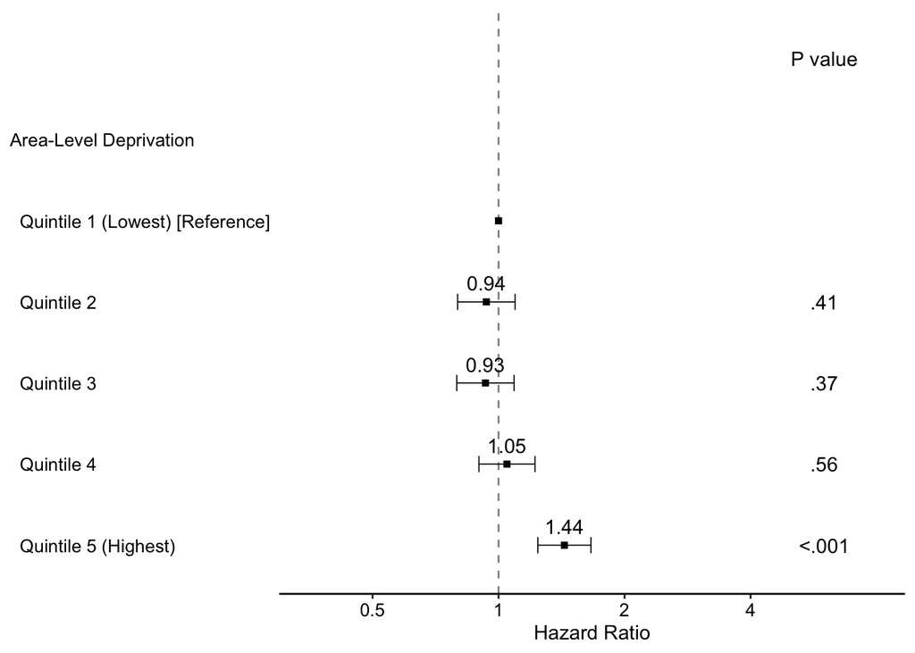

## eFigure 2

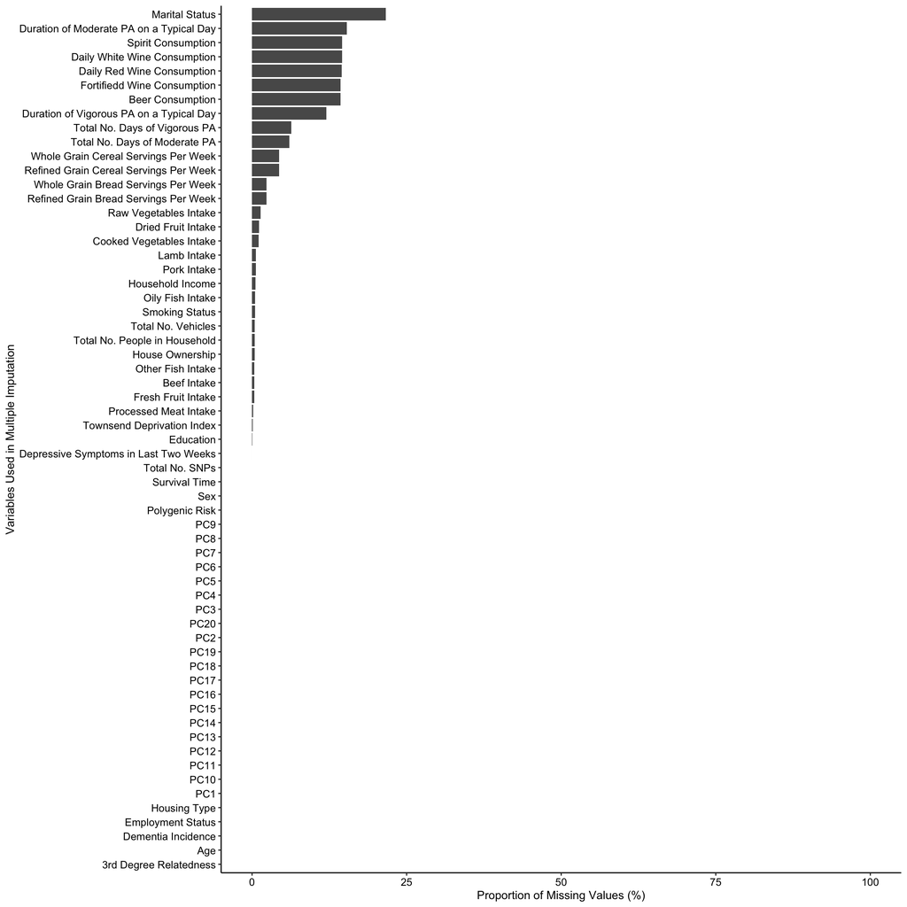

## eFigure 3. Risk of Incident Dementia by Area-Level Socioeconomic Deprivation and Genetic Risk Including Interaction Terms

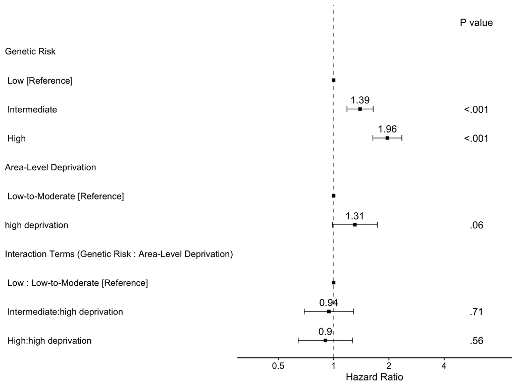

## eFigure 4. Risk of Incident Dementia by Individual-Level Socioeconomic Deprivation and Genetic Risk Including Interaction Terms

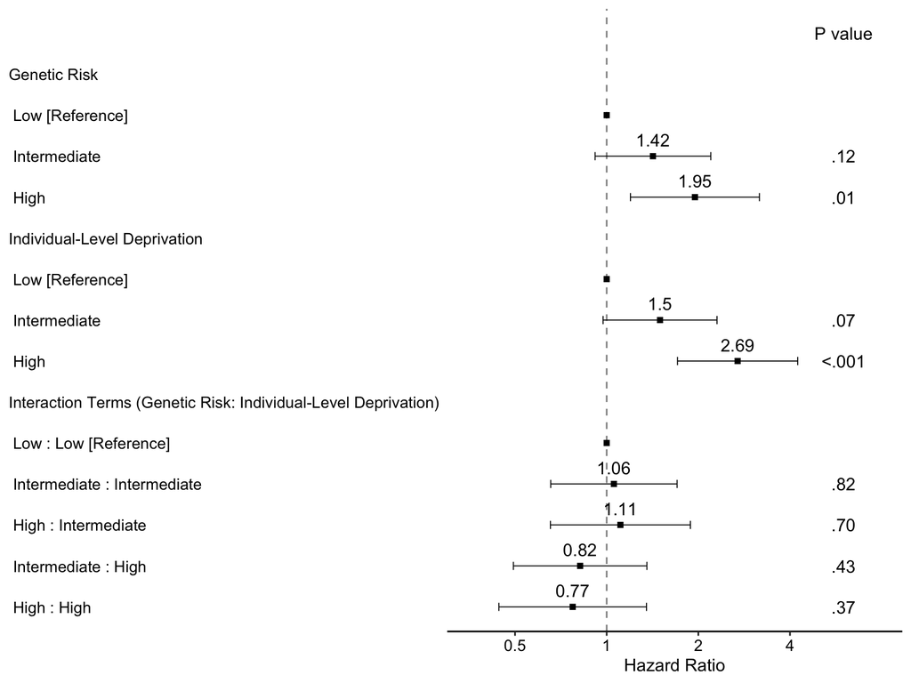